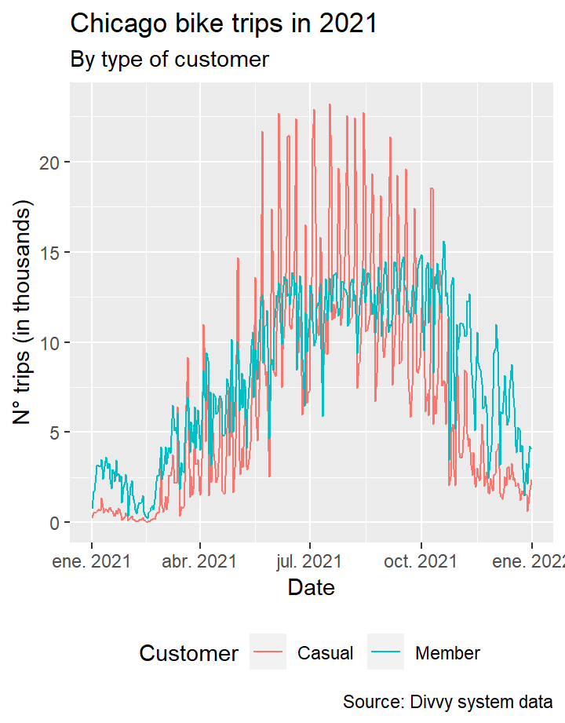

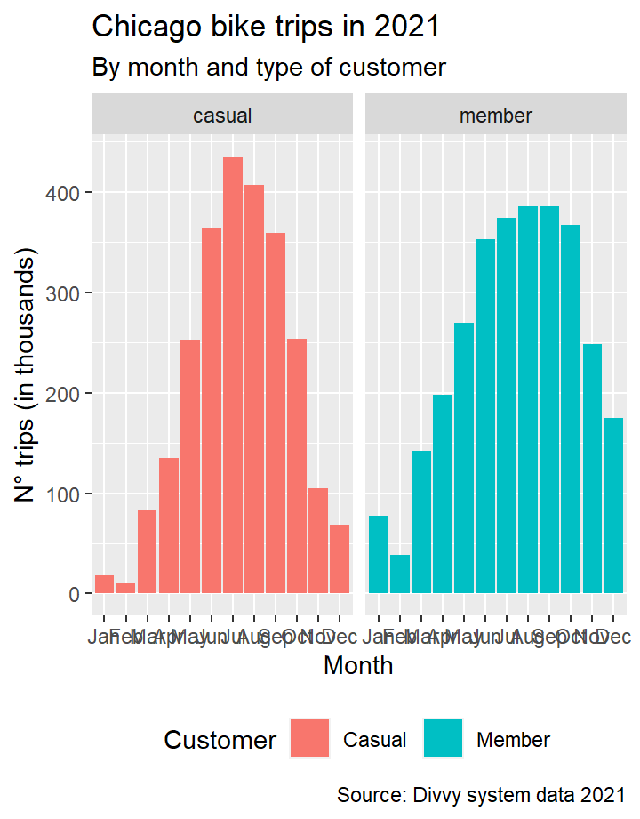

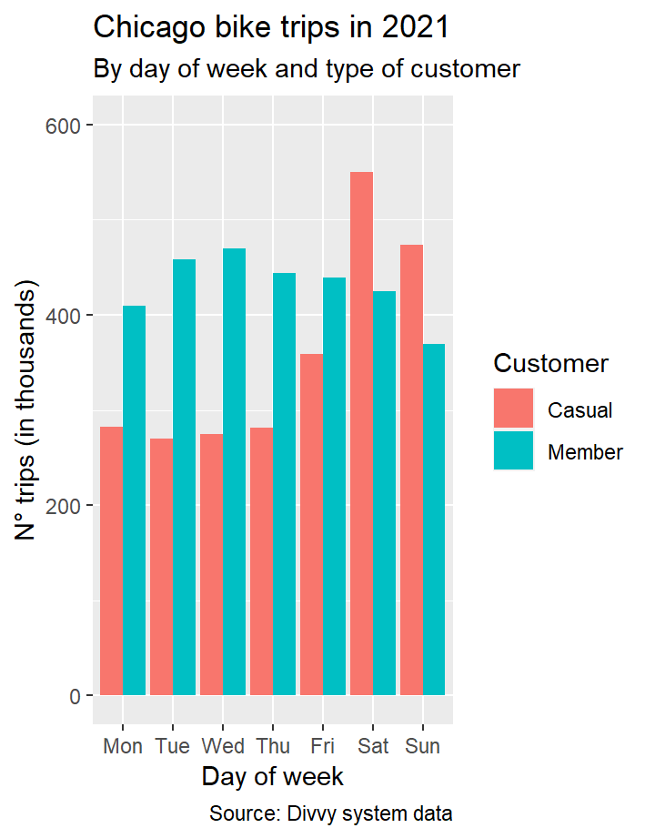

# Bike trips

### Figure 1

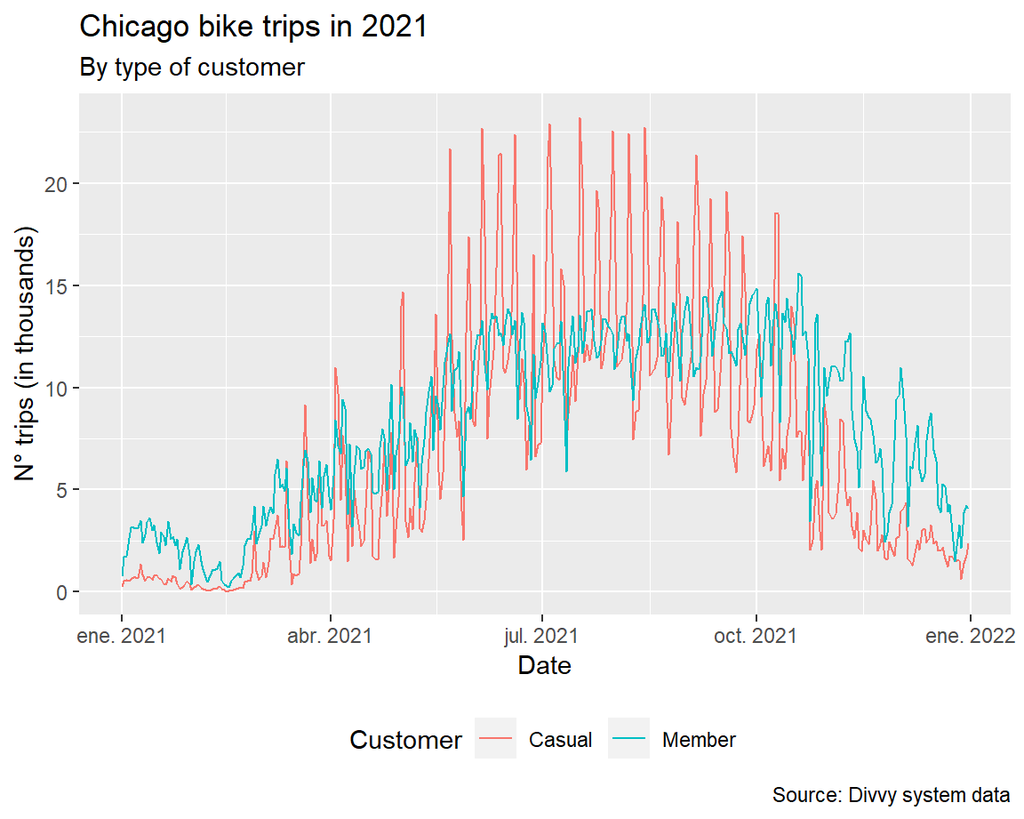

### Figure 2

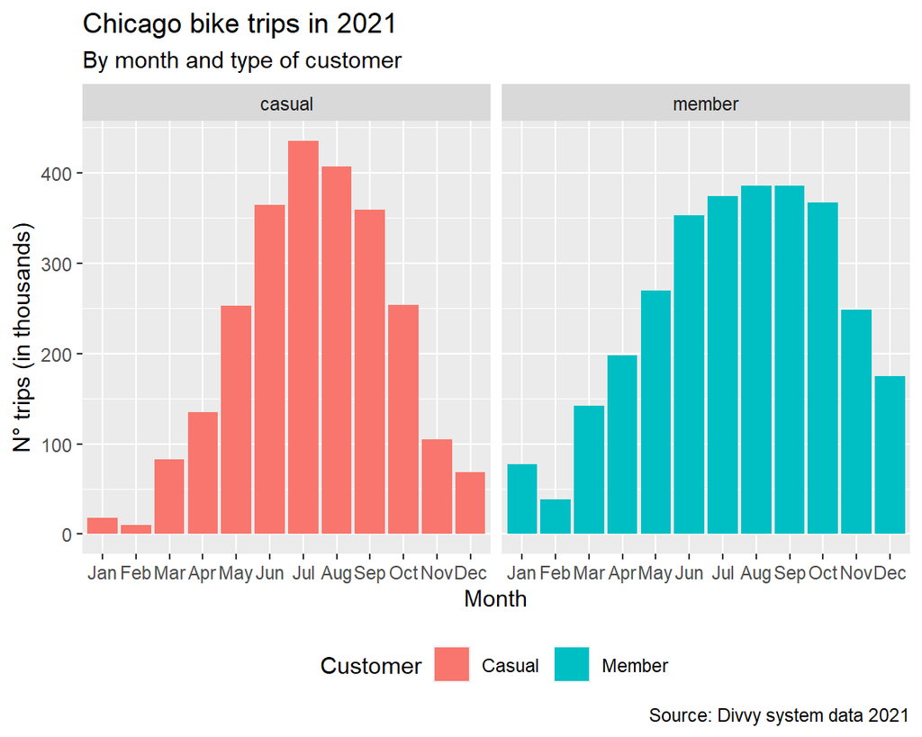

### Conclusions

From the Figure 1 we can conclude 2 important things:

- There are weekly variations because sometimes the lines of both customers have opposite directions (up and the other down).
- There are seasonal variations because both lines tend to grow towards the middle of the year and after tend to decrease.

The figures 2 and 3 examine these insights.

From the Figure 2 we can conclude:

- Casual customers rides more on summer months (june, july and august) and until the begin of the fall (september). It is possible they take advantage of the holidays, the high temperatures and better weather to go out for a bike ride.
- The same conclusion for members, however they keep higher number of trips until october.

From the Figure 3 we can conclude

- There are more bike trips on weekends for casual customers
- In the other hand, members ride more on weekdays, between tuesday and thursday.
- It it possible that members use bikes to get to work while casual customers for leisure and recreational activities

### Figure 3

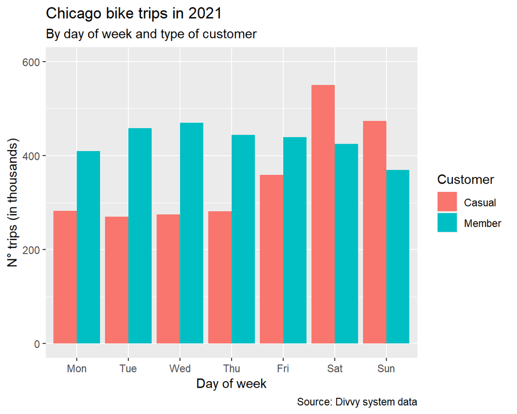

# Popular routes

### Top 10 - Members

|  | Route | Number of trips |
| --- | --- | --- |
| 1 | Ellis Ave &amp; 60th St to Ellis Ave &amp; 55th St | 4082 |
| 2 | Ellis Ave &amp; 55th St to Ellis Ave &amp; 60th St | 3652 |
| 3 | Ellis Ave &amp; 60th St to University Ave &amp; 57th St | 3109 |
| 4 | University Ave &amp; 57th St to Ellis Ave &amp; 60th St | 3010 |
| 5 | Calumet Ave &amp; 33rd St to State St &amp; 33rd St | 1989 |
| 6 | State St &amp; 33rd St to Calumet Ave &amp; 33rd St | 1954 |
| 7 | Loomis St &amp; Lexington St to Morgan St &amp; Polk St | 1860 |
| 8 | Morgan St &amp; Polk St to Loomis St &amp; Lexington St | 1653 |
| 9 | MLK Jr Dr &amp; 29th St to State St &amp; 33rd St | 1422 |
| 10 | State St &amp; 33rd St to MLK Jr Dr &amp; 29th St | 1392 |

### Top 10 - Casual riders

|  | Route | Number of trips |
| --- | --- | --- |
| 1 | Streeter Dr &amp; Grand Ave to Streeter Dr &amp; Grand Ave | 10947 |
| 2 | Millennium Park to Millennium Park | 5760 |
| 3 | Michigan Ave &amp; Oak St to Michigan Ave &amp; Oak St | 5582 |
| 4 | Lake Shore Dr &amp; Monroe St to Lake Shore Dr &amp; Monroe St | 4468 |
| 5 | Streeter Dr &amp; Grand Ave to Millennium Park | 3308 |
| 6 | Buckingham Fountain to Buckingham Fountain | 3303 |
| 7 | Theater on the Lake to Theater on the Lake | 2985 |
| 8 | DuSable Lake Shore Dr &amp; Monroe St to DuSable Lake Shore Dr &amp; Monroe St | 2937 |
| 9 | Millennium Park to Streeter Dr &amp; Grand Ave | 2925 |
| 10 | Montrose Harbor to Montrose Harbor | 2906 |